# Analysis of COVID-19 Cases in the United States

By: Alexander Quinto and Linh Le

### An Outline

- 1. Introduction
     - 1.1: COVID-19 Background Information
     - 1.2: Libraries Used
- 1. Data Collection
     - 2.1: Information about data sources
     - 2.2: Load and view data
     - 2.3: Data cleanup
- 1. Data Analysis and Visualization
     - 3.1: COVID-19 trends in the United States
     - 3.2: Breaking down COVID-19 based on demographics
- 1. Machine Learning
     - 4.1: Linear Regression Models
     - 4.2: Hypothesis testing and understanding the results
- 1. Conclusion
     - 5.1: Helpful Resources

### 1. Introduction

In this tutorial, we are going to be exploring the Data Science pipeline when it comes to data curation, parsing, data analysis and visualization, and machine learning. Throughout this tutorial, we are going to be analyzing COVID-19 cases in the United States and their relationship between the number of cases with race, sex, age groups, and ethnicity. We will also be looking at general trends in the number of COVID-19 cases throughout the United States broken down nationally, by states, and by counties. All of the data used in this tutorial is within the time frame of the beginning of 2020 until April 2021.

#### 1.1: COVID-19 Background Information

COVID-19 is the disease caused by SARS-CoV-2, the coronavirus emerged in December of 2019. Cases of COVID-19 can be severe, and has caused millions of deaths around the worlds as well as lasting health problems in individuals who have survived the illness. Coronavirus can be transmitted from person to person, and can only be diagnosed with a laboratory test. Prevention measures such as physical distancing, mask wearing, hand hygiene and staying away from others were hugely important at the beginning of the pandemic. However, as we are currently more than a year into the pandemic, COVID-19 vaccines have be authoized for emergency use the U.S. Food and Drug Adminstration, and vaccination programs continue to be in full effect across the country and in many parts of the world.

As of May 15th, the total worldwide case amount is 162 million cases with 3.36 million deaths worldwide. In the United States, as of May 15th we have a total of 33.9 million cases with 585 thousand deaths. The huge amount of cases in the United States has left us wanting to examine the relationship between the number of COVID-19 cases in the United States and race, sex, age group, ethnicity, and deaths.

#### 1.2: Libraries Used

- Pandas: this library is used to display and organize the data into data frames
- Numpy: this library is used to support our data when using Pandas
- Requests: this library is used to do HTTP requests through Python
- Matplotlib: this library is used to be able to visualized our data through graphs
- Seaborn: used for data visualization that is based on Matplotlib
- US: used to work with US and US State metadata
- Statsmodels: used to work with linear regression

```python
import pandas as pd
import requests
import numpy as np
import matplotlib.pyplot as plt
import seaborn as sns
import us
import statsmodels.api as sm
import statsmodels.formula.api as smf
from statsmodels.graphics.regressionplots import abline_plot
```

### 2. Data Collection

There are plenty of datasets that could be found online that we could of used for COVID-19 data within the United States. We settled on using data directly from the New York Times and the Centers for Disease Control and Prevention.

#### 2.1: Information about data sources

Throughout this project, there will be a total of 4 datasets being used.

The first dataset was found from the [Centers for Disease Control and Prevention](https://data.cdc.gov/Case-Surveillance/COVID-19-Case-Surveillance-Public-Use-Data-with-Ge/n8mc-b4w4):

- The CDC's public use dataset has 19 elements for all COVID-19 cases shared with the CDC and includes demographics, geography and exporsure history just to name a few fields. For our purposes will only focus on the sex, race, age group, and ethnicity fields of this particular dataset.Lastly, it is important to state that the last data points are dated from April, 2021.

The following 3 datasets were found from [The New York Times](https://github.com/nytimes/covid-19-data) github page:

- The New York Times released primary data that kept track of the daily cumulative number of cases and deaths reported in each county and state across the United States since the beginning of the pandemic. Since these datasets were stored in the NYT github account the following lines of code was used to create a file with the data. Lastly, it is important to state that the last data points are dated from May 11, 2021.
  - Dataset Fields:
    - Date: the date the cases were reported
    - County: only applicable to the dataset with counties, but lists the county name
    - State: only applicable to the dataset with states, but lists the state name
    - Fips: code which uniquely identify geographic areas
    - Cases: cumulative number of cases
    - Deaths: cumulative number of deaths
  - National US Data:

    ```
    url = 'https://raw.githubusercontent.com/nytimes/covid-19-data/master/us.csv'
      res = requests.get(url, allow_redirects=True)
      with open('us-data-nytimes.csv','wb') as file:
          file.write(res.content)
    ```

  - US Counties Data:

    ```
    url = 'https://raw.githubusercontent.com/nytimes/covid-19-data/master/us-counties.csv'
      res = requests.get(url, allow_redirects=True)
      with open('us-counties-nytimes.csv','wb') as file:
          file.write(res.content)
    ```

  - US States Data:

    ```
    url = 'https://raw.githubusercontent.com/nytimes/covid-19-data/master/us-states.csv'
      res = requests.get(url, allow_redirects=True)
      with open('us-states-nytimes.csv','wb') as file:
          file.write(res.content)
    ```

#### 2.2: Load and View Data

Since our data is stored in csv files, we will begin by creating Pandas dataframes for each of our files.

```python
# overall us data, cases and deaths are cumulative
us_data = pd.read_csv('us-data-nytimes.csv')
us_data.head()
```

|  | date | cases | deaths |
| --- | --- | --- | --- |
| 0 | 2020-01-21 | 1 | 0 |
| 1 | 2020-01-22 | 1 | 0 |
| 2 | 2020-01-23 | 1 | 0 |
| 3 | 2020-01-24 | 2 | 0 |
| 4 | 2020-01-25 | 3 | 0 |

```python
# overall us counties data, cases and deaths are cumulative
us_counties = pd.read_csv('us-counties-nytimes.csv')
us_counties.head()
```

|  | date | county | state | fips | cases | deaths |
| --- | --- | --- | --- | --- | --- | --- |
| 0 | 2020-01-21 | Snohomish | Washington | 53061.0 | 1 | 0.0 |
| 1 | 2020-01-22 | Snohomish | Washington | 53061.0 | 1 | 0.0 |
| 2 | 2020-01-23 | Snohomish | Washington | 53061.0 | 1 | 0.0 |
| 3 | 2020-01-24 | Cook | Illinois | 17031.0 | 1 | 0.0 |
| 4 | 2020-01-24 | Snohomish | Washington | 53061.0 | 1 | 0.0 |

```python
# overall us states, cases and deaths are cumulative
us_states = pd.read_csv('us-states-nytimes.csv')
us_states.head()
```

|  | date | state | fips | cases | deaths |
| --- | --- | --- | --- | --- | --- |
| 0 | 2020-01-21 | Washington | 53 | 1 | 0 |
| 1 | 2020-01-22 | Washington | 53 | 1 | 0 |
| 2 | 2020-01-23 | Washington | 53 | 1 | 0 |
| 3 | 2020-01-24 | Illinois | 17 | 1 | 0 |
| 4 | 2020-01-24 | Washington | 53 | 1 | 0 |

```python
# contains a lot of data, from cases, death, race, ethnicity, gender
demographics_us_data = pd.read_csv('total_covid19_data.csv', low_memory=False)
demographics_us_data.head()
```

|  | case_month | res_state | state_fips_code | res_county | county_fips_code | age_group | sex | race | ethnicity | case_positive_specimen_interval | case_onset_interval | process | exposure_yn | current_status | symptom_status | hosp_yn | icu_yn | death_yn | underlying_conditions_yn |
| --- | --- | --- | --- | --- | --- | --- | --- | --- | --- | --- | --- | --- | --- | --- | --- | --- | --- | --- | --- |
| 0 | 2020-02 | NaN | NaN | NaN | NaN | NaN | NaN | NaN | NaN | 6.0 | 0.0 | Missing | Missing | Laboratory-confirmed case | Symptomatic | No | Missing | No | Yes |
| 1 | 2020-02 | NaN | NaN | NaN | NaN | NaN | NaN | NaN | NaN | NaN | 0.0 | Missing | Missing | Laboratory-confirmed case | Symptomatic | No | Missing | No | NaN |
| 2 | 2020-02 | NaN | NaN | NaN | NaN | NaN | NaN | NaN | NaN | 3.0 | 0.0 | Missing | Missing | Laboratory-confirmed case | Symptomatic | No | Missing | No | Yes |
| 3 | 2020-02 | NaN | NaN | NaN | NaN | NaN | NaN | NaN | NaN | 3.0 | 0.0 | Clinical evaluation | Unknown | Laboratory-confirmed case | Symptomatic | No | No | No | NaN |
| 4 | 2020-02 | NaN | NaN | NaN | NaN | NaN | NaN | NaN | NaN | 12.0 | 0.0 | Other | Yes | Laboratory-confirmed case | Symptomatic | No | No | No | Yes |

#### 2.3: Data cleanup

Since the New York Times datasets contain cumulative amount of cases and deaths, it can become difficult to create visuals for our data if we wanted to see how many new cases or new deaths were added for each row. Below, we will add two new columns into our dataframes that will contain information regarding new cases and new deaths.

Similarly, with your demographics_us_data DataFrame we only want to keep track of race, sex, age group and ethnicity columns so any other columns we will drop from our DataFrame

```python
# since case numbers and deaths numbers are cumulative, these following lines will find the differences between the rows
# to get an accurate value of how many new cases/deaths were added per row
us_states = us_states.sort_values(by=['state', 'date'])
us_states['new_cases'] = us_states.groupby(['state'])['cases'].diff().fillna(0)
us_states['new_deaths'] = us_states.groupby(['state'])['deaths'].diff().fillna(0)

us_counties = us_counties.sort_values(by=['state','county','date'])
us_counties['new_cases'] = us_counties.groupby(['state','county'])['cases'].diff().fillna(0)
us_counties['new_deaths'] = us_counties.groupby(['state'])['deaths'].diff().fillna(0)

us_data = us_data.sort_values(by=['date'])
us_data['new_cases'] = us_data['cases'].diff().fillna(0)
us_data['new_deaths'] = us_data['deaths'].diff().fillna(0)
```

```python
demographics_us_data.drop(['res_state','res_county','state_fips_code','county_fips_code','case_positive_specimen_interval', 'case_onset_interval', 'process', 'exposure_yn', 'current_status', 'symptom_status', 'hosp_yn', 'icu_yn', 'death_yn', 'underlying_conditions_yn'], axis=1, inplace=True)
demographics_us_data.head()
```

|  | case_month | age_group | sex | race | ethnicity |
| --- | --- | --- | --- | --- | --- |
| 0 | 2020-02 | NaN | NaN | NaN | NaN |
| 1 | 2020-02 | NaN | NaN | NaN | NaN |
| 2 | 2020-02 | NaN | NaN | NaN | NaN |
| 3 | 2020-02 | NaN | NaN | NaN | NaN |
| 4 | 2020-02 | NaN | NaN | NaN | NaN |

### 3. Data Analysis and Visualization

Now that we have our data, we can begin to visualize our data by processing it to compare it with other columns in our Data Frame. Using libraries like Matplotlib and Seaborn, we are able to create graphs and plots to visualize our data.

#### 3.1: COVID-19 Cases trends in the United States

Before we take a deep dive into seeing the relationship between the number of COVID-19 cases and race, ethnicity, age group, sex. We will take a look at the general trends of COVID-19 cases in the country as well as well per state. By looking at these trends, we can understand how the our other data points might be affect because of the general decrease in cases as vaccine distribution has began on a mass scale.

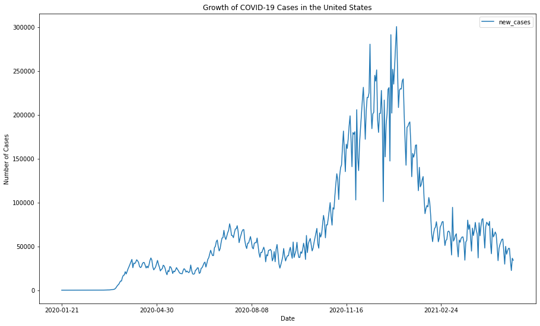

```python
# using pandas built in plot function we are able to create a line graph to show the number of cases over time
fig, ax = plt.subplots(figsize=(15,9))
us_data.plot(x='date',y='new_cases', ax = ax)
plt.ticklabel_format(style='plain', axis='y')
ax.set_title("Growth of COVID-19 Cases in the United States")
ax.set_ylabel("Number of Cases")
ax.set_xlabel("Date")
plt.show()
```

#### Number of Cases over time in the United States

Our line graph displays the general trend of COVID-19 cases in the United States over time. From a first glance, we can notice when COVID-19 began to spread throughout the US starting in mid Janurary of 2020. As more cases were added we can say that rates of transmission between the population also began to increase which also led to cases increasing into March 2020. Towards the end of March is when we saw most states releasing lockdown mandates, these restriction continued throughout the summer of 2020. As the Fall and Winter seasons approached, we began to see a huge spike in new case numbers because people were gathered more inside than they were during the summer time.

```python
max_new_cases = us_data['new_cases'].max()
print("The max number of new cases the United States added was " + str(int(max_new_cases)) + " thousand.")
date = us_data[us_data['new_cases'] == max_new_cases]
print("The highest recorded amount of new cases in the United States occured on " + date['date'].values.tolist()[0])
print("The number of new deaths reported on " + date['date'].values.tolist()[0] + " was " + str(date['new_deaths'].values.tolist()[0]))
```

```
The max number of new cases the United States added was 300669 thousand.
The highest recorded amount of new cases in the United States occured on 2021-01-08
The number of new deaths reported on 2021-01-08 was 3895.0
```

As stated before, the United States saw a huge spike of COVID-19 cases throughout the winter. This is something we can double check with our data set. Given that we were able to create a new column that keeps track of how many new cases get added per row, we can find the max value for the "new_cases" column. That is exactly what we did above, as expected the highest number of new cases added occured during the winter season.

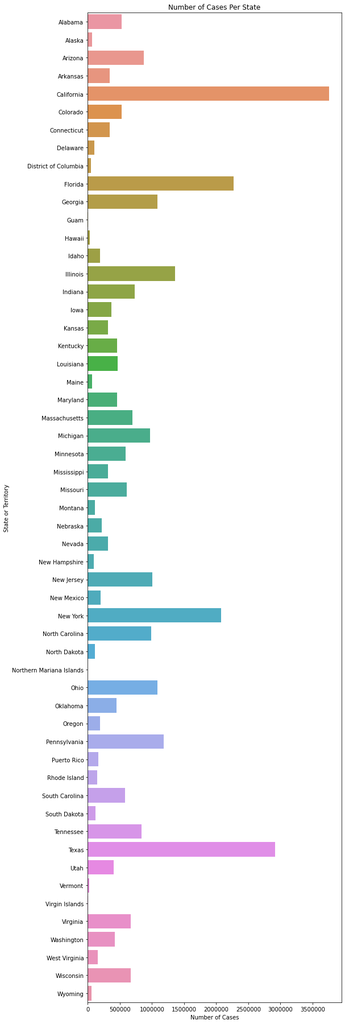

```python
# we group our dataframe based on state and and sum up the number of new cases
# we gather each name of state and terroritory
# from our new data we create a dictionary to map our state with their total number of cases
# we create a new dataframe from our new dictionary, then we are able to create a bar plot based on our new dataframe
state_name = np.unique(us_states['state'].tolist())

total = us_states.groupby(['state'])['new_cases'].sum()
case_total = total.to_frame()

names = case_total.index.tolist()
totals = case_total['new_cases'].tolist()

state_and_territories = {}

for i in range(len(names)):
    state_and_territories[names[i]] = totals[i]

state_and_territories_df = pd.DataFrame(state_and_territories.items(), columns=['State or Territory', 'Number of Cases'])

fig, ax = plt.subplots(figsize=(8,32))
sns.barplot(x=state_and_territories_df['Number of Cases'], y=state_and_territories_df['State or Territory'])
plt.ticklabel_format(style='plain', axis='x')
ax.set_title("Number of Cases Per State")
plt.show()
```

#### Number of Cases per State and Territory

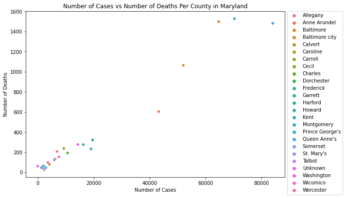

```python
# we isolate the data for the state of Maryland
# we then group our data based on county name, from there we find the total number of cases
# for each of the county and save the data into a dictionary
# we are able to create a new DataFrame and be able to plot it using seaborn
maryland_stats = us_counties[us_counties['state'] == 'Maryland']
maryland_lst = []

for i, row in maryland_stats.groupby(['county']):
    new_row = row.tail(1)
    tup = (new_row['county'].get(key=new_row['county'].index[0]), new_row['cases'].get(key=new_row['county'].index[0]), new_row['deaths'].get(key=new_row['county'].index[0]))
    maryland_lst.append(tup)

df = pd.DataFrame.from_records(maryland_lst, columns=['County', 'Cases', 'Deaths'])

fig, ax = plt.subplots(figsize=(10,6))
sns.scatterplot(x="Cases", y="Deaths", data=df,hue='County')
ax.set_title("Number of Cases vs Number of Deaths Per County in Maryland")
plt.xlabel("Number of Cases")
plt.ylabel("Number of Deaths")
plt.legend(bbox_to_anchor=(1.01,1),borderaxespad=0)
plt.tight_layout()
plt.show()
```

#### Distribution of Covid-19 cases in Maryland by counties

Once we looked further pass the states and venture into Maryland specifically, we are able to breakdown the number of cases within Maryland and plot them based off of the number of death vs number of cases by counties. This distribution shows us that there is a correlation between the number of cases vs the number of deaths, where when one increases the other increases as well. The three counties with the highest death and case toll are Prince George's, Montgomery, and Baltimore county. This definitely has correlation to the population of each county, since these three are the most populous within Maryland.

### 3.2: Breaking down COVID-19 based on Demographics

Now that we have looked at COVID-19 cases in the United States on more general spectrum, now we can try to see if there is any relationship between COVID-19 cases and certain demographics such as race, sex, age group, ethnicity

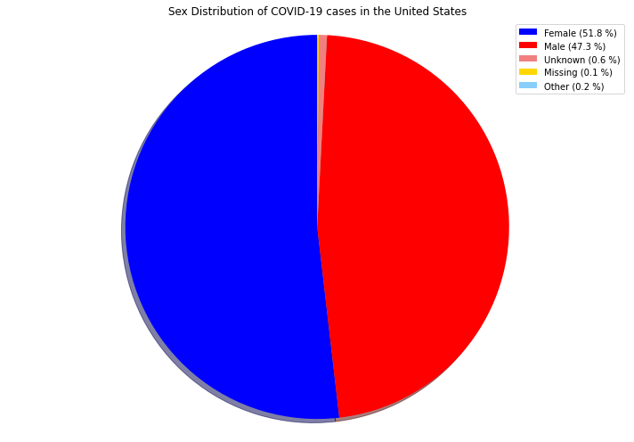

```python
# we count the total number of occurrences for each sex category
# we create labels with the percentages to make the data more easy to understand
# from there we are able to plot our data using a pie chart
ans = demographics_us_data['sex'].value_counts()
number_occur_gender = ans.values.tolist()
labels = [r'Female (51.8 %)', r'Male (47.3 %)','Unknown (0.6 %)',r'Missing (0.1 %)',r'Other (0.2 %)']
explode = (0.1,0.1,0,0,0)
colors = ['blue','red', 'lightcoral', 'gold', 'lightskyblue']
fig, ax = plt.subplots(figsize=(10,7))
patches, texts = ax.pie(number_occur_gender, colors = colors, startangle=90, shadow=True)
ax.legend(patches, labels, loc="best")
ax.axis('equal')
ax.set_title("Sex Distribution of COVID-19 cases in the United States")
plt.tight_layout()
plt.show()
```

#### Distribution of COVID-19 cases based on Sex

First, we will begin by creating a pie chart to see the percentage distribution for the number of COVID-19 cases in the United States. Based on the pie chart we generated given the distribution of COVID-19 cases in the United States gathered grouped by gender, we see that 51.8% of the COVID-19 cases in the US are Female, followed by 47.3% of Male. The rest of the data is either missing, other, or unknown. The percentage of COVID-19 cases that are females being higher than the percentage of COVID cases that are men could be a direct link to the fact that the US population contain more females.

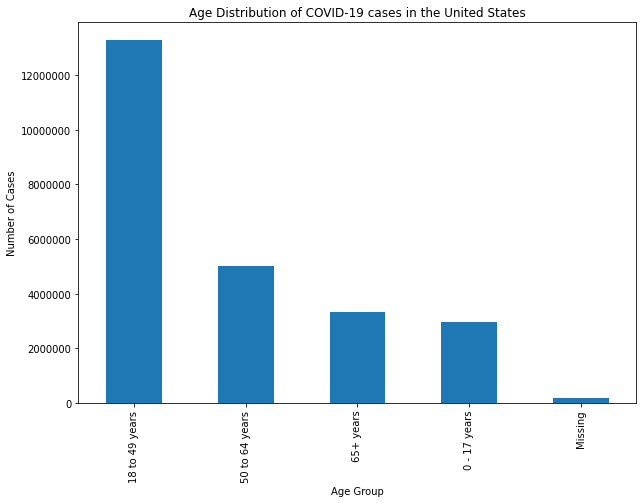

```python
# bar graph showing age distribution of covid cases in the US
# using pandas built in plot function we are able to plot the total number of occurrences for each age group
fig, ax = plt.subplots(figsize=(10,7))
demographics_us_data['age_group'].value_counts(sort=True).plot(kind='bar', ax = ax)
plt.ticklabel_format(style='plain', axis='y')
ax.set_title("Age Distribution of COVID-19 cases in the United States")
ax.set_ylabel("Number of Cases")
ax.set_xlabel("Age Group")
plt.show()
```

#### Distribution of COVID-19 cases in the United States based on Age

Now that we have looked at the relationship between sex and the number of cases in the United States, we can look at the age group breakdown for the number of cases in the United States to get an idea as to which group was affected the most. Majority of the COVID-19 cases in the United States come from the age range of 18-49 years old, with over 12 million and counting. When you combine the cases from all other age groups, it is still less then the amount of cases from the 18-49 range. This shows that the majority of COVID-19 cases fall within this age group but also the spread of COVID-19 is heavilty affected by this age range.

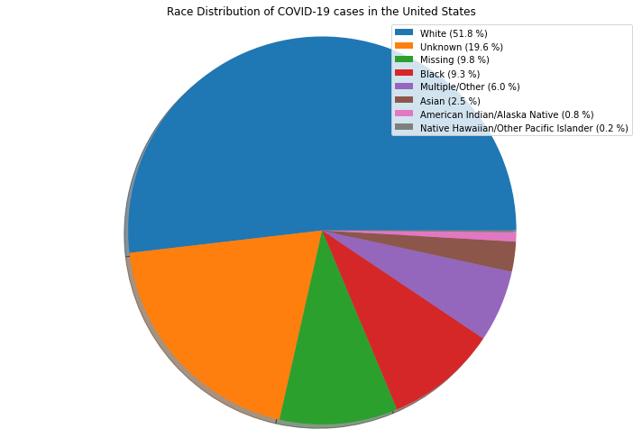

```python
# we count the total number of occurrences for each race category
# we create labels with the percentages to make the data more easy to understand
# from there we are able to plot our data using a pie chart
ans = demographics_us_data['race'].value_counts()
number_occur_race = ans.values.tolist()
labels = ['White (51.8 %)', 'Unknown (19.6 %)', 'Missing (9.8 %)', 'Black (9.3 %)', 'Multiple/Other (6.0 %)', 'Asian (2.5 %)', 'American Indian/Alaska Native (0.8 %)','Native Hawaiian/Other Pacific Islander (0.2 %)']
colors = ['blue','red', 'lightcoral', 'gold', 'lightskyblue', 'teal', 'brown', 'green']
fig, ax = plt.subplots(figsize=(10,7))
patches, texts = ax.pie(number_occur_race, shadow=True)
ax.legend(patches, labels, loc="best")
ax.axis('equal')
ax.set_title("Race Distribution of COVID-19 cases in the United States")
plt.tight_layout()
plt.show()
```

#### Distribution of COVID-19 cases in the United States based on race

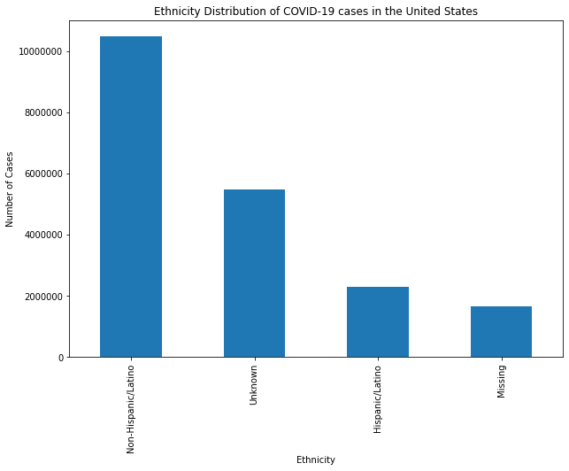

```python
# bar graph showing ethnicity distribution of covid cases in the US
# using pandas built in plot function we are able to plot the total number of occurrences for each ethnicity
fig, ax = plt.subplots(figsize=(10,7))
demographics_us_data['ethnicity'].value_counts(sort=True).plot(kind='bar', ax = ax)
plt.ticklabel_format(style='plain', axis='y')
ax.set_title("Ethnicity Distribution of COVID-19 cases in the United States")
ax.set_ylabel("Number of Cases")
ax.set_xlabel("Ethnicity")
plt.show()
```

#### Distribution of COVID-19 Cases in the United States based on ethnicity

Now that we have view the relationships between each of the columns against the number of cases, we can try to see if there is a correlation between each of the columns. However, our data needs to be manipulated before we can create a correlation matrix using pandas. Since by default our columns are just of type 'object', pandas does not allow us to create a correlation matrix with such as type.

```python
demographics_us_data.dtypes
```

```
case_month    object
age_group     object
sex           object
race          object
ethnicity     object
dtype: object
```

In order to change the types of our columns, we will use the following lines to convert from 'object' type to 'category'. The following lines, will convert them into certain categorical codes that correspond to the values within the columns. This will allow us to create the correlation matrix without any issues.

```python
demographics_us_data['case_month'].astype('string')
demographics_us_data['age_group'] = demographics_us_data['age_group'].astype('category').cat.codes
demographics_us_data['sex'] = demographics_us_data['sex'].astype('category').cat.codes
demographics_us_data['race'] = demographics_us_data['race'].astype('category').cat.codes
demographics_us_data['ethnicity']= demographics_us_data['ethnicity'].astype('category').cat.codes
```

```python
demographics_us_data.dtypes
```

```
case_month    object
age_group       int8
sex             int8
race            int8
ethnicity       int8
dtype: object
```

Now that we have manipulated our data to be able to create a correlation matrix, we can use a heatmap to help visualize our matrix. In order to interpret the matrix, we can see if there is a correlation between two variables if the color present is deeper in shade.

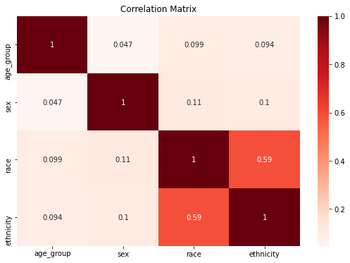

```python
# using seaborn we can create a heatmap using pandas .corr() function to create a correlation matrix
fig, ax = plt.subplots(figsize=(9,6))
sns.heatmap(demographics_us_data.corr(), annot=True, cmap='Reds')
ax.set_title("Correlation Matrix")
plt.show()
```

From the correlation matrix, we can see that ethnicity and race are obviously related to each other. Apart, from that we can see that there is a small correlation between sex and race.

### 4. Machine Learning

In the previous section, we were able to visualize the data to get a better understanding of how the number of COVID-19 cases related to age group, race, sex, and ethnicity. While our main dataset that contains demographic fields does not maintain a case count it is hard to create a datamodel surrounding that data. That is why we will continue to use the datasets from the New York Times as their datasets provide case counts.

#### 4.1: Linear Regression Models

Using our us_data DataFrame, we will try to find a linear relationship between the number of new deaths and the number of new cases in our dataset.

```python
# we are able to build our model using the statsmodel library
# we define our variables
# we print out our model
X = us_data['new_cases']
Y = us_data['new_deaths']
X = sm.add_constant(X)
md = sm.OLS(Y,X).fit()
print(md.summary())
```

```
                            OLS Regression Results
==============================================================================
Dep. Variable:             new_deaths   R-squared:                       0.483
Model:                            OLS   Adj. R-squared:                  0.482
Method:                 Least Squares   F-statistic:                     444.3
Date:                Sun, 16 May 2021   Prob (F-statistic):           4.09e-70
Time:                        20:43:50   Log-Likelihood:                -3824.4
No. Observations:                 477   AIC:                             7653.
Df Residuals:                     475   BIC:                             7661.
Df Model:                           1
Covariance Type:            nonrobust
==============================================================================
                 coef    std err          t      P>|t|      [0.025      0.975]
------------------------------------------------------------------------------
const        470.6523     49.005      9.604      0.000     374.360     566.945
new_cases      0.0109      0.001     21.079      0.000       0.010       0.012
==============================================================================
Omnibus:                      116.252   Durbin-Watson:                   0.446
Prob(Omnibus):                  0.000   Jarque-Bera (JB):              251.053
Skew:                           1.284   Prob(JB):                     3.05e-55
Kurtosis:                       5.457   Cond. No.                     1.38e+05
==============================================================================

Notes:
[1] Standard Errors assume that the covariance matrix of the errors is correctly specified.
[2] The condition number is large, 1.38e+05. This might indicate that there are
strong multicollinearity or other numerical problems.
```

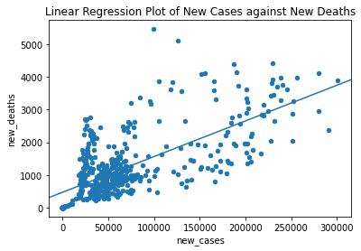

```python
# we are able to plot our model to show our linear regression line
ax = us_data.plot(x='new_cases', y='new_deaths', kind='scatter')
ax.set_title("Linear Regression Plot of New Cases against New Deaths")
abline_plot(model_results=md, ax=ax)
plt.show()
```

#### 4.2: Hypothesis testing and understanding the results

Before we can analyze our results we first have to set forth our null and alternative hypothesis.

- Null Hypothesis: There is no relationship between the number of new deaths and new cases
- Alternative Hypothesis: There is a relationship between the number of new deaths and new cases

Looking at our model summary, we can see that we have a value of 0.00 for P>|t| which is less than 0.05 meaning that it is quite significant meaning that we can reject our null hypothesis. By rejecting our null hypothesis, we can say that there is a relationship between the number of new deaths and new cases.

When also looking our model, when looking at our R-squared value will allow us to measure how well the regression line fits with the real data points. Essentially, the higher the value the better the fit for our data points. The value for R-squared is listed as 0.483, from that we can conclude that to an extent our regression line does fit some of our real data points.

Lastly, our model gives us a coefficient value. When looking at this value, if we encounter a positive value means that the two variables in this case new deaths and new cases are directly proportional. This means that where an increase in one quantity causes a corresponding increase in the other quantity.

When looking at our graph that plot our regression line, we can conclude that most of our early data points reside closer to our regression line. As the number of cases increased than we saw our data points reside much further away from our regression line.

### 5. Conclusion

#### 5.1: Helpful Resources

There have been various helpful resources that have provided us with some very good insight into our topic. To begin, for more information regarding the topic of linear regression and a very insightful tutorial can be found at this [website](https://www.datacourses.com/linear-regression-in-python-using-statsmodels-911/).

Also, it is very important to point out that the CDC contains various datasets regarding COVID-19 in the United States. These dataset can be found at this [link](https://data.cdc.gov/browse?q=COVID-19&sortBy=relevance). It is important to point out that our dataset is not the only one that could be used to create the same insights and graphs when it comes to demographics as the CDC also keep tracks of various other fields.